# Bridging Bioconductor to other bioinformatics tools using CWL

[figure not shown]

[figure not shown]

[figure not shown]

## Instructors and contact information

- [Marko Zecevic](https://github.com/markozecevic) (marko.zecevic@sbgenomics.com)
- [Daniela Cassol](https://github.com/dcassol) (danielac@ucr.edu)
- [Qiang Hu](https://github.com/hubentu) (Qiang.Hu@roswellpark.org)

## Workshop Description

This workshop starts with teaching Common Workflow Language (**CWL**) basics before it shifts off to demonstrate exciting new CWL-related Bioconductor functionality to help R-savvy bioinformaticias see it from different perspectives. The `Rcwl` and `RcwlPipelines` packages provide a simple way to wrap command line tools and build CWL data analysis pipelines programmatically in R. Also, this workshop introduces how to use `systemPipeR's` new `CWL` interface to run data analysis workflows composed of both R and command-line analysis routines. We will provide an overview of the design of the `systemPipeR's` new CWL S4 class, while the hand-on components will cover the basic usage of CWL from both within R and the command-line, as well as the construction of custom workflows.

We will present a guide and best practices for creating container images (Docker) out of your R scripts, wrapping them in CWL and then sharing them with the wider world through the public apps gallery of the Cancer Genomics Cloud (**CGC**).

Participants will be guided through a self-contained R Markdown document. Participants are encouraged to try and create a CWL wrapper for a script on their own.

## Pre-requisites

- Basic knowledge of R and usage of Bioconductor packages for NGS analysis
- Basic familiarity with running command-line tools
- No prior experience with CWL is necessary!

## Workshop Participation

Participants will be able to try out all of the functionality described. Active user participation throughout the event is highly encouraged including but not limited to lecture material, hands-on sections and final discussion.

## *R* / *Bioconductor* packages used

- [`docopt`](https://github.com/docopt/docopt.R)
- [`Rcwl`](https://bioconductor.org/packages/release/bioc/html/Rcwl.html)
- [`RcwlPipelines`](https://bioconductor.org/packages/release/bioc/html/RcwlPipelines.html)
- [`systemPipeR`](http://www.bioconductor.org/packages/release/bioc/html/systemPipeR.html)
- [`systemPipeRdata`](http://www.bioconductor.org/packages/release/data/experiment/html/systemPipeRdata.html)

### Installation

#### System dependencies

- cwltool

A python package `cwltool` is required to be installed. The cwltool is the reference implementation of the Common Workflow Language, which is used to run the CWL scripts. Here is the instruction to install the tool. https://github.com/common-workflow-language/cwltool#install

- Docker

The Docker engine requirement is optional, but it can simplify software installation and management. https://docs.docker.com/install/

- [Hisat2](https://ccb.jhu.edu/software/hisat2/manual.shtml)

`Hisat2` is required to be installed.

#### R Packages

```r
if (!requireNamespace("BiocManager", quietly=TRUE)) install.packages("BiocManager")
BiocManager::install(c("systemPipeR", "systemPipeRdata", "Rcwl", "RcwlPipelines"))
```

#### Loading packages

```r
# Loads the packages
suppressPackageStartupMessages({
library(systemPipeR)
library(systemPipeRdata)
library(Rcwl)
library(RcwlPipelines)
})
```

## Time outline

| Activity | Instructor | Time |
| --- | --- | --- |
| Introduction to `CWL` | Marko Zecevic | 15m |
| Turning your script into a command line tool | Marko Zecevic | 15m |
| `Rcwl` to wrap Bioinformatics tools | Qiang Hu | 10m |
| Write your pipeline with `Rcwl` | Qiang Hu | 20m |
| Case study | Qiang Hu | 10m |
| Overview of `systemPipeR` package | Daniela Cassol | 10m |
| Workflow Control Class | Daniela Cassol | 05m |
| Workflow Demonstration | Daniela Cassol | 25m |
| Sharing your tools | Marko Zecevic | 5m |

## Workshop goals and objectives

### Learning goals

- Integration of command-line tools via the CWL community standard
- Design of CWL workflows
- Understand how to wrap tools with `Rcwl`
- Practice building a pipeline
- Usage of a generic R-based workflow construction environment that is both scalable and reproducible

### Learning objectives

- How to make analysis workflows more robust, reproducible and portable across heterogeneous computing systems
- Create a basic `echo` tool
- Build a simple DNASeq alignment pipeline
- Usage of new CWL S4 class in `systemPipeR`

## Introduction to CWL

Sharing a data analysis pipeline which you created using ad hoc methods is a challenging task. Failure to address any detail regarding commands, tools or the environment in which the analysis is performed can hinder the reproducibility of your work.

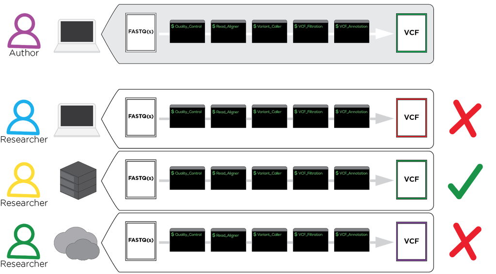

**Figure 1:** Prior modes of development: no containers (dependencies need to be harmonized), no standard workflow descriptions, executes differently in each environment.

To overcome this challenge, the bioinformatics community is embracing the use of software container technologies (such as Docker) and workflow description languages for easier documentation and replication of analysis pipelines.

Docker containers simplified how we share software, because they neatly package up code and all its dependencies, and run it in an isolated environment directly on top of the host OS. Multiple containers can run on the same machine and share the OS kernel among themselves. That makes them much smaller, more portable and less computationally intense than virtual machines.

However, containers do not come with instructions on how to execute these applications in a fashion that is human or machine-readable. This is where workflow description languages come into play. The Common Workflow Language (CWL), established in 2014, is a community-developed and widely adopted specification for describing containerized tools and workflows with plain text documents in a way that enables automation, scaling and reproducibility.

Applications described with Docker images and CWL will run consistently, in the way you intend, on everything from your local computer, your HPC, to your cloud infrastructure and various cloud platforms.

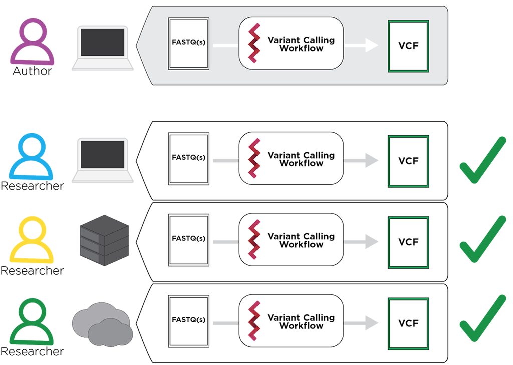

**Figure 2:** Development with standards: containers manage dependencies, standard workflow descriptions, executes the same in multiple environments.

CWL can be written in easily readable and parsable YAML, or a bit less readable, but just as parsable JSON - or a combination of both! There’s an increasing number of extensions and tooling that facilitate code development, testing, and execution. One such set of tools is the Rabix project from Seven Bridges - an open-source project that enables rapid composition and execution of CWL workflows in a manner that is scalable and reproducible. Rabix can be run locally to develop workflows on your own machine, or as a web based version that integrates directly with the Cancer Genomics Cloud (CGC) platform so you can develop and run your tools in the same place. Later on you will learn how to run CWL tools locally using SystemPipeR R package.

CWL as a standard consists of two separate specifications: CommandLineTool and Workflow. CommandLineTool describes how to execute a single command line (same as in the linux terminal), based on a set of input files and parameters. Workflow describes how multiple CommandLineTools and other Workflows are connected in an analysis.

Included in CWL CommandLineTool description:

- Class: `CommandLineTool`
- CWL version
- Tool label/id
- A list of inputs, outputs and a complete “recipe” for building the command line
- Reference to a container containing the tools with all dependencies

```
class: CommandLineTool
cwlVersion: v1.0
label: SAMtools view
id: samtools-1-6-view
baseCommand:
- /opt/samtools-1.6/samtools
- view
inputs:
- id: input_sam_file
  type: File
  inputBinding:
    position: 2
- id: output_filename
  type: string
  inputBinding:
    position: 1
    prefix: -o
    valueFrom: |-
      ${
          return inputs.output_filename + ".bam"
      }
outputs:
- id: bam_output
  type: File?
  outputBinding:
    glob: "*.bam"
arguments:
- position: 0
  prefix: ''
  valueFrom: "-S"
- position: 0
  prefix: ''
  valueFrom: "-b"
requirements:
- class: DockerRequirement
  dockerPull: images.sbgenomics.com/milana_kaljevic/samtools:1.6
- class: InlineJavascriptRequirement
```

**Figure 3:** CommandLineTool example (Samtools view).

Included in CWL Workflow description:

- Class: `Workflow`
- CWL version
- Workflow label/id
- A list of inputs and outputs
- A list of steps (individual tools) with connections

```
class: Workflow
cwlVersion: v1.0
label: SAMtools pipeline
id: samtools-1-6-pipeline
inputs:
  - id: input_sam_file
    type: File
  - id: output_filename
    type: string
outputs:
  - id: indexed_bam
    outputSource:
      - samtools_1_6_index/indexed_bam
    type: File
  - id: bam_index
    outputSource:
      - samtools_1_6_index/bam_index
    type: File
steps:
  - id: samtools_1_6_view
    in:
      - id: input_sam_file
        source: input_sam_file
      - id: output_filename
        source: output_filename
    out:
      - id: bam_output
    run: samtools-view.cwl
  - id: samtools_1_6_sort
    in:
      - id: input_bam
        source: samtools_1_6_view/bam_output
    out:
      - id: sorted_bam
    run: samtools-sort.cwl
  - id: samtools_1_6_index
    in:
      - id: sorted_input
        source: samtools_1_6_sort/sorted_bam
    out:
      - id: indexed_bam
      - id: bam_index
    run: samtools-index.cwl
```

**Figure 4:** Workflow example (Samtools view -> sort -> index).

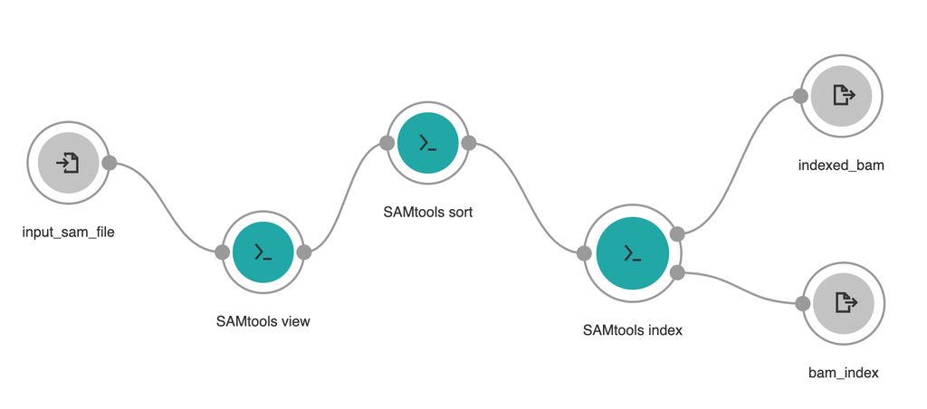

**Figure 5:** Graphical representation of a CWL workflow.

Tool/workflow descriptions like these can also be made from within R using Rcwl package functionality.

### Example use case

Perhaps you are a researcher analyzing a dataset using Bioconductor tools and are planning to share your methods and findings with the world. You want your analysis to be reproducible so that once it’s published, anyone with the access to the input data can repeat everything you’ve done and produce exactly the same outputs.

To illustrate, we will be using a short DESeq2-based script as an example:

```r
library(DESeq2)
library(pasilla)
library(ReportingTools)

directory <- system.file("extdata", package="pasilla", mustWork=TRUE)
sampleFiles <- grep("treated", list.files(directory), value=TRUE)
phenoCSV = read.csv(file.path(directory, "pasilla_sample_annotation.csv"))
designFormula <- "~type + condition"

sampleTable <- data.frame(fileName = sampleFiles,
                          filePath = file.path(directory, sampleFiles),
                          stringsAsFactors = FALSE)

ind <- match(phenoCSV[,1], tools::file_path_sans_ext(sampleTable$fileName))
sampleTable <- sampleTable[ind, , drop = FALSE]
sampleTable <- cbind(sampleTable, phenoCSV)
sampleTable <- sampleTable[complete.cases(sampleTable),]
fctr <- trimws(tail(strsplit(designFormula, "\\+")[[1]], n=1))

dds <- DESeqDataSetFromHTSeqCount(sampleTable = sampleTable,
                                  directory = "",
                                  design =  as.formula(designFormula))

dds <- DESeq(dds)

des2Report <- HTMLReport(shortName = 'DESeq2_analysis',
                         title = 'DESeq2 DE analysis on pasilla data',
                         reportDirectory = "./reports")

publish(dds, des2Report, pvalueCutoff = 0.05,
        factor = colData(dds)[,fctr],
        reportDir="./reports")

finish(des2Report)
```

In the example above, the input files used come from the [pasilla package](http://bioconductor.org/packages/release/data/experiment/html/pasilla.html). If there is a chance you or someone else will be running a similar analysis in the future, then it may be a good idea to limit the “hard-coding” of inputs and parameters and instead provide them at runtime via command-line arguments.

### The command-line interface

The first thing one needs to do in order to wrap their R/Bioconductor script into a neat portable CWL package is define the command-line interface. This can be done easily by using the R implementation of [docopt](http://docopt.org/). With docopt, by providing your script with a help message, you are at the same time defining its command line interface.

See the re-worked script below:

```r
'Docopt example

Usage:
    exscrDoc.R --counts <file>... --phenodata <file> --factor <string> [--control <string>...]

Options:

    --counts <file>     Gene counts, one file per sample.
    --phenodata <file>  Phenotype data in CSV format.
    --factor <string>   Covariate of interest.
    --control <string>  Optional parameters representing names of potential
                        confounders To be included in the design formula.
                        Must correspond to column names in the pheno data CSV.
' -> doc

library(docopt)
opts <- docopt(doc)

library(DESeq2)
library(ReportingTools)

directory <- ""

sampleFiles <- opts$counts
phenoCSV = read.csv(opts$phenodata)


designFormula <- paste0("~",paste(c(opts$control, opts$factor), collapse = '+'))

sampleTable <- data.frame(fileName = basename(sampleFiles),
                          filePath = sampleFiles,
                          stringsAsFactors = FALSE)

ind <- match(phenoCSV[,1], tools::file_path_sans_ext(sampleTable$fileName))
sampleTable <- sampleTable[ind, , drop = FALSE]
sampleTable <- cbind(sampleTable, phenoCSV)
sampleTable <- sampleTable[complete.cases(sampleTable),]

dds <- DESeqDataSetFromHTSeqCount(sampleTable = sampleTable,
                                  directory = directory,
                                  design =  as.formula(designFormula))

dds <- DESeq(dds)

des2Report <- HTMLReport(shortName = 'DESeq2_analysis',
                         title = 'DESeq2 DE analysis on pasilla data',
                         reportDirectory = "./reports")

publish(dds, des2Report, pvalueCutoff = 0.05,
        factor = colData(dds)[,opts$factor],
        reportDir="./reports")

finish(des2Report)
```

Now the script can be executed from the command line like this:

```bash
Rscript exscrDoc.R --counts /Library/Frameworks/R.framework/Versions/3.5/Resources/library/pasilla/extdata/treated1fb.txt --counts /Library/Frameworks/R.framework/Versions/3.5/Resources/library/pasilla/extdata/treated2fb.txt --counts /Library/Frameworks/R.framework/Versions/3.5/Resources/library/pasilla/extdata/treated3fb.txt --counts /Library/Frameworks/R.framework/Versions/3.5/Resources/library/pasilla/extdata/untreated1fb.txt --counts /Library/Frameworks/R.framework/Versions/3.5/Resources/library/pasilla/extdata/untreated2fb.txt --counts /Library/Frameworks/R.framework/Versions/3.5/Resources/library/pasilla/extdata/untreated3fb.txt --counts /Library/Frameworks/R.framework/Versions/3.5/Resources/library/pasilla/extdata/untreated4fb.txt --phenodata /Library/Frameworks/R.framework/Versions/3.5/Resources/library/pasilla/extdata/pasilla_sample_annotation.csv --factor condition --control type
```

Writing a help message could be considered an overkill if the tool is only going to be executed inside a CWL wrapper. An alternative would be to use `commandArgs()` and parse the arguments yourself. One way to do it is described [here](https://www.r-bloggers.com/parse-arguments-of-an-r-script/).

### Dockerizing

If you are new to Docker, the official documentation is the best place to [get started](https://docs.docker.com/get-started/)!

In short: Docker is a platform for packaging, deploying, and running applications in containers. An application that runs in a container will always run the same on every system that supports Docker. A **Docker container** is an “instance” of a **Docker image**.

An image is an executable package that includes everything needed to run an application. It is comprised of multiple read-only layers, each generated when a command from the **Dockerfile** (a recipe for building Docker images) is executed during the Docker image build.

Dockerfiles are text files that store the commands to create a Docker image. When using Dockerfiles, the process of building an image is automated as Docker reads the commands (instructions) from a Dockerfile and executes them in succession in order to create the final image. The benefit of Dockerfiles is that they document the whole procedure on how an image is created.

```
FROM ubuntu:bionic-20190515

RUN apt-get update && apt-get install -y -q python-pip && \
    pip install HTSeq==0.11.1 && \
    apt clean && \
    rm -rf /var/lib/apt/lists/*
```

A Dockerfile consists of two kinds of items: instructions followed by arguments and comments. The first instruction and argument in our example Dockerfile assign a specific ubuntu 18.04 (revision identified by the `bionic-20190515` tag) image as the base image that we build upon. After that, each command adds another layer on top. And the base image we started from is probably also made of multiple layers. Think of layers as analogous to git commits - each layer is a set of filesystem changes. When you launch a container from an image, Docker adds a read-write layer to the top of that stack of read-only layers.

The Bioconductor team maintains a [set of Docker images](https://www.bioconductor.org/help/docker/) which you can build upon. To be able to run our DESeq2 script in a container, we need to install `DESeq2` and `ReportingTools` libraries.

```
FROM bioconductor/release_base2:R3.6.0_Bioc3.9

# installing required R packages
RUN R -e 'BiocManager::install("DESeq2")'
RUN R -e 'BiocManager::install("ReportingTools")'

COPY Dockerfile /opt/
```

Building an image using the Dockerfile is really simple - just run the following command in the same directory you have placed your Dockerfile:

```bash
docker build -t bioc2019cwl:0.1.0 .
```

## Rcwl

### Introduction to Rcwl

#### Rcwl setup

```r
if (!requireNamespace("RcwlPipelines", quietly = TRUE))
    BiocManager::install(c("Rcwl", "RcwlPipelines"))
library(Rcwl)
library(RcwlPipelines)
```

#### System requirements

In addition to the R packages, the following tools are required to be installed to run the examples in this document.

- cwltool (>= 1.0.2018)
- nodejs
- Docker (optional)

The `cwltool` is the reference implementation of the Common Workflow Language, which is used to run the CWL scripts. The `nodejs` is required when the CWL scripts use the JavaScript language. The Docker containers simplify software installation and management. A CWL runner can pull the required Docker containers automatically and adjust the paths of input files.

You can find instructions to install these tools here:

- https://github.com/common-workflow-language/cwltool#install
- https://nodejs.org
- https://docs.docker.com/install

### First example

#### Hello world

The main class and constructor function is `cwlParam`, which wrap a command line tool and its parameters in a `cwlParam` object. Let’s start with a simple example, `echo hello world`.

First, we load the package and then define the input parameter for “echo”, a string without a prefix. Just an `id` option is required.

```r
input1 <- InputParam(id = "sth")
```

Second, we create a `cwlParam` object with `baseCommand` for the command to execute and `InputParamList` for the input parameters.

```r
echo <- cwlParam(baseCommand = "echo", inputs = InputParamList(input1))
```

Now we have a command object to run. Let’s send a string “Hello World!” to the object. Without defining the outputs, it will stream standard output to a temporary file by default.

```r
echo$sth <- "Hello World!"
echo
```

```
## class: cwlParam
##  cwlClass: CommandLineTool
##  cwlVersion: v1.0
##  baseCommand: echo
## inputs:
##   sth (string):  Hello World!
## outputs:
## output:
##   type: stdout
```

#### Test run

The function `runCWL` is used to run the CWL object by invoking the python tool `cwltool`. The return will be a list including the command executed, temporary output and logs. The output directory is the current folder by default, but it can be changed by setting `outdir` option. All standard out and standard error stream can also be printed by setting `stderr = ""`.

```r
r1 <- runCWL(echo, outdir = tempdir())
```

```
## Final process status is success
```

```r
r1
```

```
## List of length 3
## names(3): command output logs
```

Here we can check the output to ensure the code did what we expected.

```r
r1$output
```

```
## [1] "/tmp/RtmpdVfEC3/e5f30820236ddc66db21607c2468a6a8f59dc65e"
```

```r
readLines(r1$output)
```

```
## [1] "Hello World!"
```

The executed command was returned in the result list. It shows the command that we have defined to run.

```r
r1$command
```

```
## [1] "[job file74e6ecd3bcf.cwl] /tmp/tmpPkXAAS$ echo \\"
## [2] "    'Hello World!' > /tmp/tmpPkXAAS/e5f30820236ddc66db21607c2468a6a8f59dc65e"
```

The log shows the details of how the `cwltool` works with CWL scripts.

```r
r1$log
```

```
##  [1] "/usr/bin/cwltool 1.0.20180302231433"
##  [2] "Resolved '/tmp/RtmpdVfEC3/file74e6ecd3bcf.cwl' to 'file:///tmp/RtmpdVfEC3/file74e6ecd3bcf.cwl'"
##  [3] "[job file74e6ecd3bcf.cwl] /tmp/tmpPkXAAS$ echo \\"
##  [4] "    'Hello World!' > /tmp/tmpPkXAAS/e5f30820236ddc66db21607c2468a6a8f59dc65e"
##  [5] "[job file74e6ecd3bcf.cwl] completed success"
##  [6] "{"
##  [7] "    \"output\": {"
##  [8] "        \"checksum\": \"sha1$a0b65939670bc2c010f4d5d6a0b3e4e4590fb92b\", "
##  [9] "        \"basename\": \"e5f30820236ddc66db21607c2468a6a8f59dc65e\", "
## [10] "        \"location\": \"file:///tmp/RtmpdVfEC3/e5f30820236ddc66db21607c2468a6a8f59dc65e\", "
## [11] "        \"path\": \"/tmp/RtmpdVfEC3/e5f30820236ddc66db21607c2468a6a8f59dc65e\", "
## [12] "        \"class\": \"File\", "
## [13] "        \"size\": 13"
## [14] "    }"
## [15] "}"
## [16] "Final process status is success"
```

The `runCWL` generated two scripts with the default `tempfile` prefix, the tool wrapper CWL file and the input YML file. The `cwltool` parses the two scripts and translates them into the command shown before. The output is not defined in the `cwlParam` object, so the command output was returned to **stdout** by default.

### Components

#### Input Parameters

1. Essential Input parameters

For the input parameters, three options need to be defined usually, *id*, *type*, and *prefix*. The type can be *string*, *int*, *long*, *float*, *double*, and so on. More detail can be found at: https://www.commonwl.org/v1.0/CommandLineTool.html#CWLType.

Here is an example from the CWL user guide(http://www.commonwl.org/user_guide/03-input/). We defined the `echo` with different type of input parameters by `InputParam`, and the `stdout` option can be used to caputre the standard output stream into a file:

```r
e1 <- InputParam(id = "flag", type = "boolean", prefix = "-f")
e2 <- InputParam(id = "string", type = "string", prefix = "-s")
e3 <- InputParam(id = "int", type = "int", prefix = "-i")
e4 <- InputParam(id = "file", type = "File",
                 prefix = "--file=", separate = FALSE)
echoA <- cwlParam(baseCommand = "echo",
                  inputs = InputParamList(e1, e2, e3, e4),
                  stdout = "output.txt")
```

Then we give it a try by assigning values to the inputs.

```r
echoA$flag <- TRUE
echoA$string <- "Hello"
echoA$int <- 1

tmpfile <- tempfile()
write("World", tmpfile)
echoA$file <- tmpfile

r2 <- runCWL(echoA, outdir = tempdir())
```

```
## Final process status is success
```

```r
r2$command
```

```
## [1] "[job file74e191ce7a6.cwl] /tmp/tmp4H58AA$ echo \\"
## [2] "    --file=/tmp/tmph1U6jI/stg31a66bbb-bffb-445a-bb2f-1bbb76b657d9/file74e2f6cadd4 \\"
## [3] "    -f \\"
## [4] "    -i \\"
## [5] "    1 \\"
## [6] "    -s \\"
## [7] "    Hello > /tmp/tmp4H58AA/output.txt"
```

2. Array Inputs

Taking a similar example to the CWL user guide described above, we can define three different type of array as inputs:

```r
a1 <- InputParam(id = "A", type = "string[]", prefix = "-A")
a2 <- InputParam(id = "B",
                 type = InputArrayParam(items = "string",
                                        prefix="-B=", separate = FALSE))
a3 <- InputParam(id = "C", type = "string[]", prefix = "-C=",
                 itemSeparator = ",", separate = FALSE)
echoB <- cwlParam(baseCommand = "echo",
                 inputs = InputParamList(a1, a2, a3))
```

We then set values for the three inputs:

```r
echoB$A <- letters[1:3]
echoB$B <- letters[4:6]
echoB$C <- letters[7:9]
echoB
```

```
## class: cwlParam
##  cwlClass: CommandLineTool
##  cwlVersion: v1.0
##  baseCommand: echo
## inputs:
##   A (string[]): -A a b c
##   B:
##     type: array
##     prefix: -B= d e f
##   C (string[]): -C= g h i
## outputs:
## output:
##   type: stdout
```

Now we can check whether the command behaves as we expected.

```r
r3 <- runCWL(echoB, outdir = tempdir())
```

```
## Final process status is success
```

```r
r3$command
```

```
## [1] "[job file74e54d0973c.cwl] /tmp/tmpkIw5vd$ echo \\"
## [2] "    -A \\"
## [3] "    a \\"
## [4] "    b \\"
## [5] "    c \\"
## [6] "    -B=d \\"
## [7] "    -B=e \\"
## [8] "    -B=f \\"
## [9] "    -C=g,h,i > /tmp/tmpkIw5vd/dcdffbce5830a2633fd272d0b99a60019c591388"
```

#### Output Parameters

1. Capturing Output

The outputs, similar to the inputs, is a list of output parameters. Three options, *id*, *type* and *glob*, can be defined. The *glob* option is used to define a pattern to find files relative to the output directory.

Here is an example to unzip a compressed `gz` file. First, we generate a compressed R script file:

```r
zzfil <- file.path(tempdir(), "sample.R.gz")
zz <- gzfile(zzfil, "w")
cat("sample(1:10, 5)", file = zz, sep = "\n")
close(zz)
```

We then define a `cwlParam` object to use “gzip” to uncompress an input file:

```r
ofile <- "sample.R"
z1 <- InputParam(id = "uncomp", type = "boolean", prefix = "-d")
z2 <- InputParam(id = "out", type = "boolean", prefix = "-c")
z3 <- InputParam(id = "zfile", type = "File")
o1 <- OutputParam(id = "rfile", type = "File", glob = ofile)
gz <- cwlParam(baseCommand = "gzip",
               inputs = InputParamList(z1, z2, z3),
               outputs = OutputParamList(o1),
               stdout = ofile)
```

Now the `gz` object can be used to uncompress the previously generated compressed file:

```r
gz$uncomp <- TRUE
gz$out <- TRUE
gz$zfile <- zzfil
r4 <- runCWL(gz, outdir = tempdir())
```

```
## Final process status is success
```

```r
r4$output
```

```
## [1] "/tmp/RtmpdVfEC3/sample.R"
```

Or we can use `arguments` to set some default parameters:

```r
z1 <- InputParam(id = "zfile", type = "File")
o1 <- OutputParam(id = "rfile", type = "File", glob = ofile)
Gz <- cwlParam(baseCommand = "gzip",
               arguments = list("-d", "-c"),
               inputs = InputParamList(z1),
               outputs = OutputParamList(o1),
               stdout = ofile)
Gz
```

```
## class: cwlParam
##  cwlClass: CommandLineTool
##  cwlVersion: v1.0
##  baseCommand: gzip
## arguments: -d -c
## inputs:
##   zfile (File):
## outputs:
## rfile:
##   type: File
##   outputBinding:
##     glob: sample.R
## stdout: sample.R
```

```r
Gz$zfile <- zzfil
r4a <- runCWL(Gz, outdir = tempdir())
```

```
## Final process status is success
```

To make it for general usage, we can define a pattern with javascript to *glob* the output, which requires `node` to be installed in your system PATH:

```r
pfile <- "$(inputs.zfile.path.split('/').slice(-1)[0].split('.').slice(0,-1).join('.'))"
```

Or we can directly use the CWL built in file property, `nameroot`:

```r
pfile <- "$(inputs.zfile.nameroot)"
o2 <- OutputParam(id = "rfile", type = "File", glob = pfile)
req1 <- list(class = "InlineJavascriptRequirement")
GZ <- cwlParam(baseCommand = c("gzip", "-d", "-c"),
               requirements = list(), ## assign list(req1) if node installed.
               inputs = InputParamList(z1),
               outputs = OutputParamList(o2),
               stdout = pfile)
GZ$zfile <- zzfil
r4b <- runCWL(GZ, outdir = tempdir())
```

```
## Final process status is success
```

2. Array Outputs

We can also capture multiple output files with `glob` pattern:

```r
a <- InputParam(id = "a", type = InputArrayParam(items = "string"))
b <- OutputParam(id = "b", type = OutputArrayParam(items = "File"),
                 glob = "*.txt")
touch <- cwlParam(baseCommand = "touch",
                  inputs = InputParamList(a),
                  outputs = OutputParamList(b))
touch$a <- c("a.txt", "b.gz", "c.txt")
r5 <- runCWL(touch, outdir = tempdir())
```

```
## Final process status is success
```

```r
r5$output
```

```
## [1] "/tmp/RtmpdVfEC3/a.txt" "/tmp/RtmpdVfEC3/c.txt"
```

### Run approaches

#### Running Tools in parallel

The CWL can also work in high performance clusters with batch-queuing system, such as SGE, PBS, SLURM and so on, using the Bioconductor package `BiocParallel`. Here is an example to submit jobs with “Multiicore” and “SGE”, seperately:

```r
library(BiocParallel)
sth.list <- as.list(LETTERS)
names(sth.list) <- LETTERS

## submit with mutlicore
result1 <- runCWLBatch(cwl = echo, outdir = tempdir(),
                       inputList = list(sth = sth.list),
                       BPPARAM = MulticoreParam(4))

## submit with SGE
result2 <- runCWLBatch(cwl = echo, outdir = tempdir(),
                       inputList = list(sth = sth.list),
                       BPPARAM = BatchtoolsParam(workers = 4, cluster = "sge",
                                                 resources = list(queue = "all.q")))
```

#### Web Application

Here we build a tool with different types of input parameters:

```r
e1 <- InputParam(id = "flag", type = "boolean",
                 prefix = "-f", doc = "boolean flag")
e2 <- InputParam(id = "string", type = "string", prefix = "-s")
e3 <- InputParam(id = "option", type = "string", prefix = "-o")
e4 <- InputParam(id = "int", type = "int", prefix = "-i", default = 123)
e5 <- InputParam(id = "file", type = "File",
                 prefix = "--file=", separate = FALSE)
e6 <- InputParam(id = "array", type = "string[]", prefix = "-A",
                 doc = "separated by comma")
mulEcho <- cwlParam(baseCommand = "echo", id = "mulEcho",
                 label = "Test parameter types",
                 inputs = InputParamList(e1, e2, e3, e4, e5, e6),
                 stdout = "output.txt")
mulEcho
```

```
## class: cwlParam
##  cwlClass: CommandLineTool
##  cwlVersion: v1.0
##  baseCommand: echo
## inputs:
##   flag (boolean): -f
##   string (string): -s
##   option (string): -o
##   int (int): -i 123
##   file (File): --file=
##   array (string[]): -A
## outputs:
## output:
##   type: stdout
## stdout: output.txt
```

Some input parameters can be predefined in a list, which will be converted to selected options in the webapp. An `upload` parameter can be used to generate an upload interface for the file type option. If `FALSE` is set for `upload`, the upload field will be text input (file path) instead of file input.

[figure not shown]

```r
inputList <- list(option = c("option1", "option2"))
app <- cwlShiny(mulEcho, inputList, upload = TRUE)
runApp(app)
```

**Figure 6:** Shiny webApp for `mulEcho`.

### Wrap R command-line tool

Let’s wrap the previous “exscrDoc.R” with `Rcwl`.

```r
sysdir <- system.file(package="BioC19CWL")
rtool <- file.path(sysdir, "vignettes", "extdata", "exscrDoc.R")
p1 <- InputParam(id = "counts",
                 type = InputArrayParam(items = "File",
                                        prefix = "--counts"))
p2 <- InputParam(id = "phenodata", type = "File",
                 prefix = "--phenodata")
p3 <- InputParam(id = "factor", type = "string", prefix = "--factor")
p4 <- InputParam(id = "control", type = "string", prefix = "--control")
o1 <- OutputParam(id = "outdir", type = "Directory", glob = "reports")
DE <- cwlParam(baseCommand = c("Rscript", rtool),
               inputs = InputParamList(p1, p2, p3, p4),
               outputs = OutputParamList(o1))
```

We can test the tool using data from the “pasilla” package.

```r
DE$counts <- list.files(system.file("extdata", package = "pasilla"),
                        "treat", full.names = TRUE)
DE$phenodata <- system.file("extdata/pasilla_sample_annotation.csv",
                            package = "pasilla")
DE$factor <- "condition"
DE$control <- "type"
DEres <- runCWL(DE, outdir = tempdir())
```

Here are the command and results:

```r
head(DEres$command)
head(DEres$output)
```

[output not shown]

### Build a simple DNASeq pipeline

#### RcwlPipelines package

The R scripts to build the CWL tools and pipelines based on the `Rcwl` package are stored in the “tools” and “pipelines” folder respectively in the `RcwlPipelines` package. The function `cwlTools` can be used to catalog the available scripts, where the `cachePath` can be your existing cache directory or a new folder:

```r
tools <- cwlTools(cachePath = tempdir())
tools
```

```
## class: BiocFileCache
## bfccache: /tmp/RtmpdVfEC3
## bfccount: 36
## For more information see: bfcinfo() or bfcquery()
```

The full paths can be pulled from the “fpath” column.

```r
suppressPackageStartupMessages(library(dplyr))
bfcinfo(tools) %>% select(rname, fpath)
```

```
## # A tibble: 36 x 2
##    rname           fpath
##    <chr>           <chr>
##  1 blastn          /home/qian/R/x86_64-pc-linux-gnu-library/3.6/RcwlPipeli…
##  2 bowtie2_align   /home/qian/R/x86_64-pc-linux-gnu-library/3.6/RcwlPipeli…
##  3 bowtie2_build   /home/qian/R/x86_64-pc-linux-gnu-library/3.6/RcwlPipeli…
##  4 bwa_index       /home/qian/R/x86_64-pc-linux-gnu-library/3.6/RcwlPipeli…
##  5 bwa             /home/qian/R/x86_64-pc-linux-gnu-library/3.6/RcwlPipeli…
##  6 cutadapt        /home/qian/R/x86_64-pc-linux-gnu-library/3.6/RcwlPipeli…
##  7 fastQC          /home/qian/R/x86_64-pc-linux-gnu-library/3.6/RcwlPipeli…
##  8 featureCounts   /home/qian/R/x86_64-pc-linux-gnu-library/3.6/RcwlPipeli…
##  9 geneBody_cover… /home/qian/R/x86_64-pc-linux-gnu-library/3.6/RcwlPipeli…
## 10 genePredToBed   /home/qian/R/x86_64-pc-linux-gnu-library/3.6/RcwlPipeli…
## # … with 26 more rows
```

#### Build a pipeline

A pipline can be built by utilizing the tools cataloged by the `tools`. For example, a simple alignment pipelines with mapping and marking duplicates can be built from the `tools`.

First, we load the required tools, bwa, samtools and picard markduplicates.

```r
scripts <- bfcinfo(tools) %>%
    filter(rname %in% c("bwa",
                        "samtools_samTobam",
                        "samtools_sortBam",
                        "samtools_index",
                        "markdup")) %>%
    pull(rpath)
invisible(sapply(scripts, source))
```

Next, we define the input parameters.

```r
p1 <- InputParam(id = "threads", type = "int")
p2 <- InputParam(id = "RG", type = "string")
p3 <- InputParam(id = "Ref", type = "File",
                 secondaryFiles =
                     c(".amb", ".ann", ".bwt", ".pac", ".sa"))
p4 <- InputParam(id = "FQ1", type = "File")
p5 <- InputParam(id = "FQ2", type = "File?")
```

Then we define the pipeline steps, from raw fastqs to duplicates marked alignments.

```r
## bwa
s1 <- Step(id = "bwa", run = bwa,
           In = list(threads = "threads",
                     RG = "RG",
                     Ref = "Ref",
                     FQ1 = "FQ1",
                     FQ2 = "FQ2"))
## sam to bam
s2 <- Step(id = "sam2bam", run = sam2bam,
           In = list(sam = "bwa/sam"))
## sort bam
s3 <- Step(id = "sortBam", run = sortBam,
           In = list(bam = "sam2bam/bam"))
## mark duplicates
s4 <- Step(id = "markdup", run = markdup,
           In = list(ibam = "sortBam/sbam",
                     obam = list(
                         valueFrom="$(inputs.ibam.nameroot).mdup.bam"),
                     matrix = list(
                         valueFrom="$(inputs.ibam.nameroot).markdup.txt")))
## index bam
s5 <- Step(id = "idxBam", run = samtools_index,
           In = list(bam = "markdup/mBam"))
```

Last, we define the outputs and connect the steps to a new pipeline.

```r
req1 <- list(class = "StepInputExpressionRequirement")
req2 <- list(class = "InlineJavascriptRequirement")
## outputs
o1 <- OutputParam(id = "Bam", type = "File", outputSource = "markdup/mBam")
o2 <- OutputParam(id = "Idx", type = "File", outputSource = "idxBam/idx")
## stepParam
Align <- cwlStepParam(requirements = list(req1, req2),
                      inputs = InputParamList(p1, p2, p3, p4, p5),
                      outputs = OutputParamList(o1, o2))
## build pipeline
Align <- Align + s1 + s2 + s3 + s4 + s5
```

The pipeline is ready for use. We can plot the pipeline with `plotCWL` from the `Rcwl` package.

```r
plotCWL(Align)
```

[interactive chart not shown]

**Figure 7:** Visualization for the pipeline `Align`.

Let’s test the pipeline.

```r
library(BiocParallel)
ids <- c("normal", "tumor")
fq1 <- list.files(file.path(sysdir, "vignettes", "extdata"), "1.fq.gz", full.names = TRUE)
fq2 <- list.files(file.path(sysdir, "vignettes", "extdata"), "2.fq.gz", full.names = TRUE)
fq1 <- as.list(fq1)
fq2 <- as.list(fq2)
rg <- as.list(paste("@RG",
                    paste0("ID:", ids),
                    paste0("SM:", ids), sep = "\\t"))
names(fq1) <- names(fq2) <- names(rg) <- ids

inputList <- list(RG = rg,
                  FQ1 = fq1,
                  FQ2 = fq2)
paramList <- list(threads = 2,
                  Ref = file.path(sysdir, "vignettes", "extdata", "ref.fa"))

result <- runCWLBatch(cwl = Align, outdir = tempdir(), inputList,
                      paramList, BPPARAM = MulticoreParam(2),
                      stderr = "", cwlTemp=TRUE)
```

Check the results:

```r
dir(file.path(tempdir(), "normal"))
```

[output not shown]

### Rcwl tutorial

https://hubentu.github.io/others/Rcwl

## *systemPipeR*’s New CWL Command-line Interface

### Overview

*`systemPipeR`* provides utilities for building and running automated end-to-end analysis workflows for a wide range of research applications, including next generation sequence (NGS) experiments (Backman and Girke 2016). Important features include a uniform workflow interface across different data analysis applications, automated report generation, and support for running both R and command-line software, such as NGS aligners or peak/variant callers, on local computers or compute clusters (Fig. 8). The latter supports interactive job submissions and batch submissions to queuing systems of clusters. The main motivation and advantages of using *`systemPipeR`* for complex data analysis tasks are:

1. Facilitates design of complex NGS workflows involving multiple R/Bioconductor packages
2. Common workflow interface for different NGS applications
3. Makes NGS analysis with Bioconductor utilities more accessible to new users
4. Simplifies usage of command-line software from within R
5. Reduces complexity of using compute clusters for R and command-line software
6. Accelerates runtime of workflows via parallelzation
7. Improves reproducibility by automating analyses and generation of analysis reports

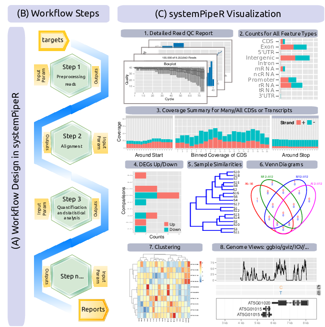

**Figure 8:** Relevant features in *`systemPipeR`*. Workflow design concepts are illustrated under (A & B). Examples of *`systemPipeR’s`* visualization functionalities are given under (C).

This tutorial introduces how to use *`systemPipeR's`* new CWL (Common Workflow Language) interface to run data analysis workflows composed of both R and command-line analysis routines. In previous versions, *`systemPipeR`* used a custom command-line interface for this purpose which will continue to be supported for some time. With the latest Bioconductor Release 3.9, we are adopting for this functionality the widely used community standard CWL for describing analysis workflows in a generic and reproducible manner. Using this community standard in *`systemPipeR`* has many advantages. For instance, the integration of CWL allows to run *`systemPipeR`* workflows from a single specification instance either entirely from within R, from various command-line wrappers (e.g. *`cwl-runner`*) or from other languages (*e.g.* Bash or Python). This includes support for both command-line and R/Bioconductor software as well as resources for containerization, parallel evaluations on computer clusters along with automated generation of interactive analysis reports.

An important feature of *`systemPipeR's`* CWL interface is that it provides two options to run command-line tools and workflows based on CWL. First, one can run CWL in its native way via an R-based wrapper utility for `cwl-runner` or `cwl-tools` (CWL-based approach). Second, one can run workflows using CWL’s command-line and workflow instructions from within R (R-based approach). In the latter case the same CWL workflow definition files (*e.g.* `*.cwl` and `*.yml`) are used but rendered and exectuted entirely with R functions defined by *`systemPipeR`*, and thus use CWL mainly as a command-line and workflow definition format rather than a software to run workflows. In this regard *`systemPipeR`* also provides several convenience functions that are useful for designing and debugging workflows, such as a command-line rendering function to retrieve the exact command-line strings for each data set and processing step prior to running a command-line.

This overview also introduces the design of a new CWL S4 class in *`systemPipeR`* combined with examples of the basic usage of CWL from both within R and the command-line, as well as the construction of custom workflows. A short use-case demonstration will guide users through basic steps of an RNA-Seq profiling workflow that will include read mappings with variable parameter settings of popular short-read aligners (*e.g.* HISAT2 or STAR), read quantification and statistical analyses steps as well as automation routines for running NGS workflows from start to finish with a single command. The last part will demonstrate how to parallelize the analysis of a relatively large NGS data sets on multiple CPU cores of single machines as well as computer clusters with a scheduler (*e.g.* Slurm).

### Getting Started

#### Installation

The *`systemPipeR`* package can be installed from the R console using the [*`BiocManager::install`*](https://cran.r-project.org/web/packages/BiocManager/index.html) command. The associated data package [*`systemPipeRdata`*](https://github.com/tgirke/systemPipeRdata) can be installed the same way. The latter is a helper package for generating *`systemPipeR`* workflow environments with a single command containing all parameter files and sample data required to quickly test and run sample workflows.

```r
if(!requireNamespace("BiocManager", quietly=TRUE))
    install.packages("BiocManager")
BiocManager::install("systemPipeR")
BiocManager::install("systemPipeRdata")
```

#### Load Package

```r
library("systemPipeR") # Loads the package
# library(help="systemPipeR") # Lists package info
# vignette("systemPipeR") # Opens vignette
```

### Run Environment

#### Load Sample Workflow

Sample workflows can be loaded with the `genWorkenvir` function from `systemPipeRdata`. The following commands load an RNA-Seq workflow that includes 36 FASTQ files from SRA entry [`SRP010938`](http://www.ncbi.nlm.nih.gov/sra/?term=SRP010938) corresponding to 18 paired-end (PE) read sets from *Arabidposis thaliana* (Howard et al. 2013). To minimize processing time during testing, each of the 36 FASTQ files has been subsetted to 90,000-100,000 randomly sampled PE reads that map to the first 100,000 nucleotides of each chromosome in the *A. thalina* genome. The corresponding reference genome sequence (FASTA) and its GFF annotion file have been truncated accordingly, and are included in the workflow as well. After these truncations, the entire test data set requires less than 200MB disk space. A PE read set has been chosen here for flexibility, because it can be used for testing both types of analysis routines requiring either SE (single end) or PE reads.

```r
library(systemPipeRdata)
genWorkenvir(workflow="rnaseq")
setwd("rnaseq")
```

#### Directory Structure

- **workflow/** (*e.g.* *rnaseq/*)
  - This is the root directory of the R session running the workflow.
  - Run script ( *.Rmd) and sample annotation (*targets.txt*) files are located here.
  - Note, this directory can have any name (*e.g.* **rnaseq**, **varseq**). Changing its name does not require any modifications in the run script(s).
  - **Important subdirectories**:
    - **param/**
      - Stores non-CWL parameter files such as: *.param, *.tmpl and *.run.sh. These files are only required for backwards compatibility to run old workflows using the previous custom command-line interface.
      - **param/cwl/**: This subdirectory stores all the CWL parameter files. To organize workflows, each can have its own subdirectory, where all `CWL param` and `input.yml` files need to be in the same subdirectory.
    - **data/**
      - FASTQ files
      - FASTA file of reference (*e.g.* reference genome)
      - Annotation files
      - etc.
    - **results/**
      - Analysis results are usually written to this directory, including: alignment, variant and peak files (BAM, VCF, BED); tabular result files; and image/plot files
      - Note, the user has the option to organize results files for a given sample and analysis step in a separate subdirectory.

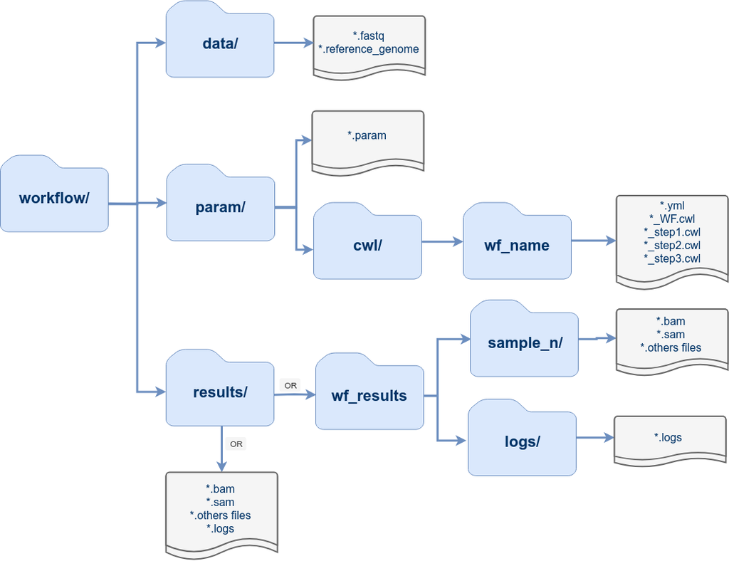

**Figure 9:** *systemPipeR’s* preconfigured directory structure.

The following parameter files are included in each workflow template:

1. *`targets.txt`*: initial one provided by user; downstream *`targets_*.txt`* files are generated automatically
2. *`*.param/cwl`*: defines parameter for input/output file operations, *e.g.*:
   - *`hisat2-se/hisat2-mapping-se.cwl`*
   - *`hisat2-se/hisat2-mapping-se.yml`*
3. *`*_run.sh`*: optional bash scripts
4. Configuration files for computer cluster environments (skip on single machines):
   - *`.batchtools.conf.R`*: defines the type of scheduler for *`batchtools`* pointing to template file of cluster, and located in user’s home directory
   - *`*.tmpl`*: specifies parameters of scheduler used by a system, *e.g.* Torque, SGE, Slurm, etc.

#### Workflow Design

*`systemPipeR`* workflows can be run from start-to-finish with a single command or stepwise in interactive mode from the R console. The connectivity among workflow steps is achieved by the *`SYSargs2`* workflow control class (see Fig. 10). This S4 class is a list-like container where each instance stores all the input/output paths and parameter components requried for a particular data analysis step. *`SYSargs2`* instances are generated by two constructor functions, *`loadWorkflow`* and *`renderWF`*, using as data input *`targets`* or *`yaml`* files as well as two *cwl* parameter files (for details see below). When running preconfigured workflows, the only input the user needs to provide is the initial *`targets`* file containing the paths to the input files (*e.g.* FASTQ) along with unique sample labels. Subsequent targets instances are created automatically. The parameters required for running command-line software are provided by the parameter (*`.cwl`*) files described below.

We also introduce the *`SYSargs2Pipe`* class that organizes one or many SYSargs2 containers in a single compound object capturing all information required to run, control and monitor complex workflows from start to finish. This design enhances the *`systemPipeR`* workflow framework with a generalized, flexible, and robust design.

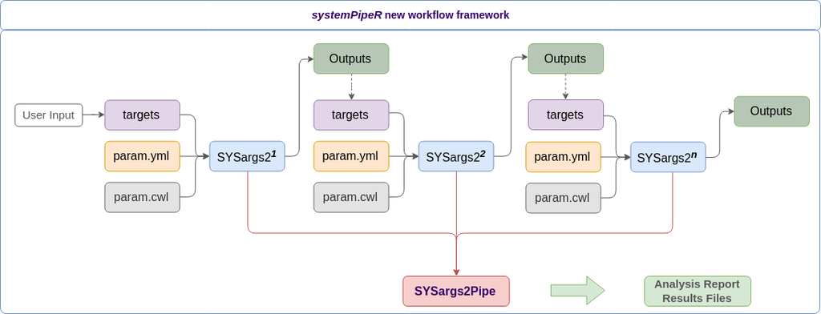

**Figure 10:** Workflow steps with input/output file operations are controlled by *`SYSargs2`* objects. Each *`SYSargs2`* instance is constructed from one *targets* and two *param* files. The only input provided by the user is the initial *targets* file. Subsequent *targets* instances are created automatically, from the previous output files. Any number of predefined or custom workflow steps are supported. One or many *`SYSargs2`* objects are organized in a *`SYSargs2Pipe`* container.

### Usage of *`SYSargs2`*

#### Sample Inputs: *`targets`* file

The *`targets`* file defines all input files (*e.g.* FASTQ, BAM, BCF) and if necessary sample comparisons of an analysis workflow. The following shows the format of a sample *`targets`* file included in the package. It also can be viewed and downloaded from *`systemPipeR`*’s GitHub repository [here](https://github.com/tgirke/systemPipeR/blob/master/inst/extdata/targets.txt). In a target file with a single type of input files, here FASTQ files of single end (SE) reads, the first three columns are mandatory including their column names, while it is four mandatory columns for FASTQ files of PE reads. All subsequent columns are optional and any number of additional columns can be added as needed.

Users should note here, the usage of targets files is optional when using *`systemPipeR's`* new CWL interface. They can be replaced by a standard YAML input file used by CWL. Since for organizing experimental variables targets files are extremely useful and user-friendly. Thus, we encourage users to keep using them.

```r
library(systemPipeR)
targetspath <- system.file("extdata", "targets.txt", package="systemPipeR")
read.delim(targetspath, comment.char = "#")[1:4,1:4]
```

```
##                      FileName SampleName Factor SampleLong
## 1 ./data/SRR446027_1.fastq.gz        M1A     M1  Mock.1h.A
## 2 ./data/SRR446028_1.fastq.gz        M1B     M1  Mock.1h.B
## 3 ./data/SRR446029_1.fastq.gz        A1A     A1   Avr.1h.A
## 4 ./data/SRR446030_1.fastq.gz        A1B     A1   Avr.1h.B
```

To work with custom data, users need to generate a *`targets`* file containing the paths to their own FASTQ files and then provide under *`targetspath`* the path to the corresponding *`targets`* file. For paired-end (PE) samples, the structure of the targets file is similar, where users need to provide two FASTQ path columns: *`FileName1`* and *`FileName2`* with the paths to the PE FASTQ files.

If needed sample comparisons can be defined in the header lines of the *`targets`* file starting with ‘`# <CMP>`’.

```r
readLines(targetspath)[1:4]
```

```
## [1] "# Project ID: Arabidopsis - Pseudomonas alternative splicing study (SRA: SRP010938; PMID: 24098335)"
## [2] "# The following line(s) allow to specify the contrasts needed for comparative analyses, such as DEG identification. All possible comparisons can be specified with 'CMPset: ALL'."
## [3] "# <CMP> CMPset1: M1-A1, M1-V1, A1-V1, M6-A6, M6-V6, A6-V6, M12-A12, M12-V12, A12-V12"
## [4] "# <CMP> CMPset2: ALL"
```

The function *`readComp`* imports the comparison information and stores it in a *`list`*. Alternatively, *`readComp`* can obtain the comparison information from the corresponding *`SYSargs2`* object (see below). Note, these header lines are optional. They are mainly useful for controlling comparative analyses according to certain biological expectations, such as identifying differentially expressed genes in RNA-Seq experiments based on simple pair-wise comparisons.

```r
readComp(file=targetspath, format="vector", delim="-")
```

```
## $CMPset1
## [1] "M1-A1"   "M1-V1"   "A1-V1"   "M6-A6"   "M6-V6"   "A6-V6"   "M12-A12"
## [8] "M12-V12" "A12-V12"
##
## $CMPset2
##  [1] "M1-A1"   "M1-V1"   "M1-M6"   "M1-A6"   "M1-V6"   "M1-M12"  "M1-A12"
##  [8] "M1-V12"  "A1-V1"   "A1-M6"   "A1-A6"   "A1-V6"   "A1-M12"  "A1-A12"
## [15] "A1-V12"  "V1-M6"   "V1-A6"   "V1-V6"   "V1-M12"  "V1-A12"  "V1-V12"
## [22] "M6-A6"   "M6-V6"   "M6-M12"  "M6-A12"  "M6-V12"  "A6-V6"   "A6-M12"
## [29] "A6-A12"  "A6-V12"  "V6-M12"  "V6-A12"  "V6-V12"  "M12-A12" "M12-V12"
## [36] "A12-V12"
```

#### Construct *`SYSargs2`*

*`SYSargs2`* stores all the information and instructions needed for processing a set of input files with a single or many command-line steps within a workflow (*i.e.* several components of a software or several independent software tools). The *`SYSargs2`* object is created and fully populated with the *`loadWorkflow`* and *`renderWF`* functions, respectively.

In CWL, files with the extension *`.cwl`* define the parameters of a chosen command-line step or workflow, while files with the extension *`.yml`* define the input variables of command-line steps. Note, input variables provided by a *`targets`* file can be passed on to a *`SYSargs2`* instance via the *`inputvars`* argument of the *`renderWF`* function.

```r
hisat2.cwl <- system.file("extdata", "cwl/hisat2-se/hisat2-mapping-se.cwl", package="systemPipeR")
yaml::read_yaml(hisat2.cwl)
```

```
## $cwlVersion
## [1] "v1.0"
##
## $class
## [1] "CommandLineTool"
##
## $doc
## [1] "[HISAT2](https://ccb.jhu.edu/software/hisat2/index.shtml): graph-based alignment of next generation sequencing reads to a population of genomes"
##
## $label
## [1] "Last updated 02/2019"
##
## $hints
## $hints$SoftwareRequirement
## $hints$SoftwareRequirement$packages
## $hints$SoftwareRequirement$packages[[1]]
## $hints$SoftwareRequirement$packages[[1]]$package
## [1] "hisat2"
##
## $hints$SoftwareRequirement$packages[[1]]$version
## [1] "2.1.0"
##
##
##
##
##
## $baseCommand
## [1] "hisat2"
##
## $requirements
## $requirements$InitialWorkDirRequirement
## $requirements$InitialWorkDirRequirement$listing
## [1] "$(inputs.results_path)"
##
##
##
## $arguments
## $arguments[[1]]
## $arguments[[1]]$prefix
## [1] "-S"
```

[output cut: 112 more lines]

```
## [1] "Path to the results directory"
##
## $inputs$results_path$type
## [1] "Directory"
##
##
##
## $outputs
## $outputs$hisat2_sam
## $outputs$hisat2_sam$type
## [1] "File"
##
## $outputs$hisat2_sam$outputBinding
## $outputs$hisat2_sam$outputBinding$glob
## [1] "$(inputs.results_path.basename)/$(inputs.SampleName).sam"
```

```r
hisat2.yml <- system.file("extdata", "cwl/hisat2-se/hisat2-mapping-se.yml", package="systemPipeR")
yaml::read_yaml(hisat2.yml)
```

```
## $hisat2_idx_basedir
## $hisat2_idx_basedir$class
## [1] "Directory"
##
## $hisat2_idx_basedir$path
## [1] "./data"
##
##
## $hisat2_idx_basename
## [1] "tair10.fasta"
##
## $fq1
## $fq1$class
## [1] "File"
##
## $fq1$path
## [1] "_FASTQ_PATH_"
##
##
## $SampleName
## [1] "_SampleName_"
##
## $results_path
## $results_path$class
## [1] "Directory"
##
## $results_path$path
## [1] "./results"
##
##
## $thread
## [1] 4
##
## $ModulesToLoad
## $ModulesToLoad$module1
## [1] "hisat2/2.0.1"
##
## $ModulesToLoad$module2
## [1] "samtools/1.9"
```

The following imports a *`.cwl`* file (here *`hisat2-mapping-se.cwl`*) for running the short read aligner HISAT2 (Kim, Langmead, and Salzberg 2015). The *`loadWorkflow`* and *`renderWF`* functions render the proper command-line strings for each sample and software tool.

```r
library(systemPipeR)
targets <- system.file("extdata", "targets.txt", package="systemPipeR")
dir_path <- system.file("extdata/cwl/hisat2-se", package="systemPipeR")
WF <- loadWorkflow(targets=targets, wf_file="hisat2-mapping-se.cwl",
                   input_file="hisat2-mapping-se.yml",
                   dir_path=dir_path)

WF <- renderWF(WF, inputvars=c(FileName="_FASTQ_PATH_", SampleName="_SampleName_"))
```

Several accessor methods are available that are named after the slot names of the *`SYSargs2`* object.

```r
names(WF)
```

```
##  [1] "targets"       "targetsheader" "modules"       "wf"
##  [5] "clt"           "yamlinput"     "cmdlist"       "input"
##  [9] "output"        "cwlfiles"      "inputvars"
```

Of particular interest is the *`cmdlist()`* method. It constructs the system commands for running command-line software as specified by a given *`.cwl`* file combined with the paths to the input samples (*e.g.* FASTQ files) provided by a *`targets`* file. The example below shows the *`cmdlist()`* output for running HISAT2 on the first SE read sample. Evaluating the output of *`cmdlist()`* can be very helpful for designing and debugging *`.cwl`* files of new command-line software or changing the parameter settings of existing ones.

```r
cmdlist(WF)[1]
```

```
## $M1A
## $M1A$`hisat2-mapping-se.cwl`
## [1] "hisat2 -S results/M1A.sam  -x ./data/tair10.fasta  -k 1  --min-intronlen 30  --max-intronlen 3000  -U ./data/SRR446027_1.fastq.gz --threads 4"
```

```r
modules(WF)
```

```
##        module1        module2
## "hisat2/2.0.1" "samtools/1.9"
```

```r
targets(WF)[1]
```

```
## $M1A
## $M1A$FileName
## [1] "./data/SRR446027_1.fastq.gz"
##
## $M1A$SampleName
## [1] "M1A"
##
## $M1A$Factor
## [1] "M1"
##
## $M1A$SampleLong
## [1] "Mock.1h.A"
##
## $M1A$Experiment
## [1] 1
##
## $M1A$Date
## [1] "23-Mar-2012"
```

```r
targets.as.df(targets(WF))[1:4,1:4]
```

```
##                      FileName SampleName Factor SampleLong
## 1 ./data/SRR446027_1.fastq.gz        M1A     M1  Mock.1h.A
## 2 ./data/SRR446028_1.fastq.gz        M1B     M1  Mock.1h.B
## 3 ./data/SRR446029_1.fastq.gz        A1A     A1   Avr.1h.A
## 4 ./data/SRR446030_1.fastq.gz        A1B     A1   Avr.1h.B
```

```r
output(WF)[1]
```

```
## $M1A
## $M1A$`hisat2-mapping-se.cwl`
## [1] "results/M1A.sam"
```

```r
cwlfiles(WF)
```

```
## $cwl
## [1] "/home/qian/R/x86_64-pc-linux-gnu-library/3.6/systemPipeR/extdata/cwl/hisat2-se/hisat2-mapping-se.cwl"
##
## $yml
## [1] "/home/qian/R/x86_64-pc-linux-gnu-library/3.6/systemPipeR/extdata/cwl/hisat2-se/hisat2-mapping-se.yml"
```

```r
inputvars(WF)
```

```
## $FileName
## [1] "_FASTQ_PATH_"
##
## $SampleName
## [1] "_SampleName_"
```

```r
infile1(WF)[1:2]
```

```
##                                                                         M1A
## "/home/qian/workspace/BioC19CWL/vignettes/rnaseq/data/SRR446027_1.fastq.gz"
##                                                                         M1B
## "/home/qian/workspace/BioC19CWL/vignettes/rnaseq/data/SRR446028_1.fastq.gz"
```

The output components of *`SYSargs2`* define the expected output files for each step in the workflow; some of which are the input for the next workflow step, here next *`SYSargs2`* instance (see Fig. 10).

```r
output(WF)[1]
```

```
## $M1A
## $M1A$`hisat2-mapping-se.cwl`
## [1] "results/M1A.sam"
```

In an ‘R-centric’ rather than a ‘CWL-centric’ workflow design the connectivity among workflow steps is established by writing all relevant output with the *writeTargetsout* function to a new targets file that serves as input to the next *loadWorkflow* and *renderWF* call. By chaining several *`SYSargs2`* steps together one can construct complex workflows involving many sample-level input/output file operations with any combination of command-line or R-based software. Alternatively, a CWL-centric workflow design can be used that defines all/most workflow steps with CWL workflow and parameter files. Due to time and space restrictions the CWL-centric approach is not covered by this tutorial.

### Workflow Demonstration

The following steps will demonstrate how to use the short read aligner HISAT2 (Kim, Langmead, and Salzberg 2015) in both interactive job submissions and batch submissions to queuing systems of clusters. Analysis of differentially expressed genes (DEGs) will also be performed. Subsequently, it will be demonstrated how to execute the entire workflow with one command, while rendering at the same time the corresponding analysis report.

#### Alignment with `HISAT2`

```r
targets <- system.file("extdata", "targets.txt", package="systemPipeR")
dir_path <- system.file("extdata/cwl/hisat2-se", package="systemPipeR")
align <- loadWorkflow(targets=targets, wf_file="hisat2-mapping-se.cwl",
                   input_file="hisat2-mapping-se.yml",
                   dir_path=dir_path)
align <- renderWF(align, inputvars=c(FileName="_FASTQ_PATH_", SampleName="_SampleName_"))
align
```

```
## Instance of 'SYSargs2':
##    Slot names/accessors:
##       targets: 18 (M1A...V12B), targetsheader: 4 (lines)
##       modules: 2
##       wf: 0, clt: 1, yamlinput: 7 (components)
##       input: 18, output: 18
##       cmdlist: 18
##    WF Steps:
##       1. hisat2-mapping-se.cwl (rendered: TRUE)
```

Subsetting *`SYSargs2`* class slots for each workflow step.

```r
subsetWF(align, slot="input", subset='FileName')[1:2]
```

```
##                           M1A                           M1B
## "./data/SRR446027_1.fastq.gz" "./data/SRR446028_1.fastq.gz"
```

```r
subsetWF(align, slot="output", subset=1)[1:2]
```

```
##               M1A               M1B
## "results/M1A.sam" "results/M1B.sam"
```

```r
subsetWF(align, slot="step", subset=1)[1] ## subset all the HISAT2 commandline
```

```
##                                                                                                                                             M1A
## "hisat2 -S results/M1A.sam  -x ./data/tair10.fasta  -k 1  --min-intronlen 30  --max-intronlen 3000  -U ./data/SRR446027_1.fastq.gz --threads 4"
```

```r
subsetWF(align, slot="output", subset=1, delete=TRUE)[1] ##DELETE
```

```
## The subset cannot be deleted: no such file
```

```
##               M1A
## "results/M1A.sam"
```

##### Interactive Job Submissions in a Single Machine

To simplify the short read alignment execution for the user, the command-line can be run with the *`runCommandline`* function. The execution will be on a single machine without submitting to a queuing system of a computer cluster. This way, the input FASTQ files will be processed sequentially. By default *`runCommandline`* auto detects SAM file outputs and converts them to sorted and indexed BAM files, using internally the `Rsamtools` package (Morgan et al. 2019). Besides, *`runCommandline`* allows the user to create a dedicated results folder for each step in the workflow and a sub-folder for each sample defined in the *targets* file. This includes the output and log files for each step.

```r
cmdlist(align)[1:2]
system("hisat2-build ./data/tair10.fasta ./data/tair10.fasta")
runCommandline(align, make_bam = FALSE) ## generates alignments and writes *.sam files to ./results folder
runCommandline(align, dir=TRUE, make_bam = TRUE) ## same as above but writes files to ./results/workflowName/Samplename folders and converts *.sam files to sorted and indexed BAM files
```

Check and update the output location if necessary.

```r
align <- output_update(align, dir=TRUE, replace = ".bam") ## Updates the output(align) to the right location in the subfolders
output(align)
```

Check whether all BAM files have been created with the constructing superclass *`SYSargs2Pipe`*.

```r
WF_track <- run_track(WF_ls = c(align))
names(WF_track)
WF_steps(WF_track)
track(WF_track)
summaryWF(WF_track)
```

##### Parallelization on Clusters

The short read alignment steps can be parallelized on a computer cluster that uses a queueing/scheduling system such as Slurm. For this the *`clusterRun`* function submits the computing requests to the scheduler using the run specifications defined by *`runCommandline`*.

```r
library(batchtools)
resources <- list(walltime=120, ntasks=1, ncpus=4, memory=1024)
reg <- clusterRun(align, FUN = runCommandline, more.args = list(dir=TRUE),
                  conffile = ".batchtools.conf.R", template = "batchtools.slurm.tmpl",
                  Njobs=18, runid="01", resourceList=resources)
getStatus(reg=reg)

align <- output_update(align, dir=TRUE, replace = ".bam") ## Updates the output(align) to the right location in the subfolders
output(align)
```

#### Alignment Stats

The following provides an overview of the number of reads in each sample and how many of them aligned to the reference.

```r
read_statsDF <- alignStats(args=align)
write.table(read_statsDF, "results/alignStatsWF.xls", row.names=FALSE, quote=FALSE, sep="\t")
read_statsDF
```

#### Create New targets File

To establish the connectivity to the next workflow step, one can write a new *targets* file with the *`writeTargetsout`* function. The new *targets* file serves as input to the next *`loadWorkflow`* and *`renderWF`* call.

```r
names(clt(align))
writeTargetsout(x=align, file="default", step=1)
```

#### Read Quantification

##### Read counting with `summarizeOverlaps` in parallel mode using multiple cores

Reads overlapping with annotation ranges of interest are counted for each sample using the `summarizeOverlaps` function (Lawrence et al. 2013). In the given example, the read counting is preformed for exonic gene regions in a non-strand-specific manner while ignoring overlaps among different genes. The raw read count table (`countDFeByg.xls`) is written to a file in the *results* directory of this project. Parallelization is achieved with the `BiocParallel` package.

```r
library("GenomicFeatures"); library(BiocParallel)
txdb <- makeTxDbFromGFF(file="data/tair10.gff", format="gff",
                        dataSource="TAIR", organism="Arabidopsis thaliana")
saveDb(txdb, file="./data/tair10.sqlite")
txdb <- loadDb("./data/tair10.sqlite")
(align <- readGAlignments(outpaths(args)[1])) # Demonstrates how to read bam file into R
eByg <- exonsBy(txdb, by=c("gene"))
bfl <- BamFileList(outpaths(args), yieldSize=50000, index=character())
multicoreParam <- MulticoreParam(workers=2); register(multicoreParam)
registered()
counteByg <- bplapply(bfl, function(x) summarizeOverlaps(eByg, x, mode="Union",
                                                         ignore.strand=TRUE,
                                                         inter.feature=FALSE,
                                                         singleEnd=TRUE))
countDFeByg <- sapply(seq(along=counteByg),
                      function(x) assays(counteByg[[x]])$counts)
rownames(countDFeByg) <- names(rowRanges(counteByg[[1]]))
colnames(countDFeByg) <- names(bfl)
write.table(countDFeByg, "results/countDFeByg.xls", col.names=NA,
            quote=FALSE, sep="\t")
```

Sample data slice of count table

```r
read.delim("results/countDFeByg.xls", row.names=1, check.names=FALSE)[1:4,1:5]
```

#### DEG Analysis with *`DESeq2`*

The following *`run_DESeq2`* function is a convenience wrapper for identifying DEGs in batch mode with *`DESeq2`* (Love, Huber, and Anders 2014) for any number of pairwise sample comparisons specified under the *`cmp`* argument. Users are strongly encouraged to consult the [*`DESeq2`*](http://bioconductor.org/packages/DESeq2/) vignette for more detailed information on this topic and how to properly run *`DESeq2`* on data sets with more complex experimental designs.

```r
targets <- read.delim(targetspath, comment="#")
cmp <- readComp(file=targetspath, format="matrix", delim="-")
cmp[[1]]
```

```
##       [,1]  [,2]
##  [1,] "M1"  "A1"
##  [2,] "M1"  "V1"
##  [3,] "A1"  "V1"
##  [4,] "M6"  "A6"
##  [5,] "M6"  "V6"
##  [6,] "A6"  "V6"
##  [7,] "M12" "A12"
##  [8,] "M12" "V12"
##  [9,] "A12" "V12"
```

```r
countDFeBygpath <- system.file("extdata", "countDFeByg.xls",
                               package="systemPipeR")
countDFeByg <- read.delim(countDFeBygpath, row.names=1)
degseqDF <- run_DESeq2(countDF=countDFeByg, targets=targets,
                       cmp=cmp[[1]], independent=FALSE)
```

Filter and plot DEG results for up and down regulated genes.

```r
DEG_list2 <- filterDEGs(degDF=degseqDF, filter=c(Fold=2, FDR=10))
```

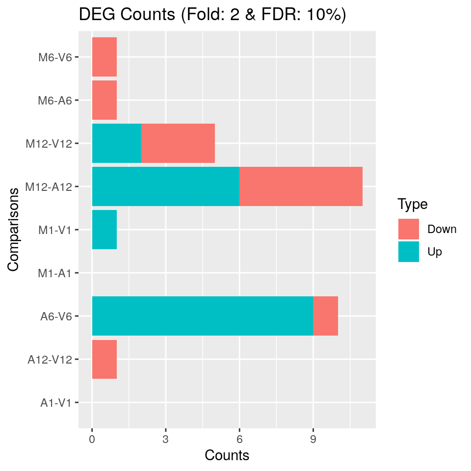

**Figure 11:** Up and down regulated DEGs identified by *`DESeq2`*.

#### Run with Single Command

Workflows can be run interactively from the R console. Alternatively, it is possible to run an entire workflows or their components from the command-line. The following shows how to execute a workflow (*e.g.*, systemPipeRNAseq.Rmd) from the command-line. During the evaluation of the code chunks in the corresponding `*.Rmd` file the analysis report is generated in HTML and/or PDF format(s).

```r
Rscript -e "rmarkdown::render('systemPipeRNAseq.Rmd')"
```

### Funding

This project is funded by NSF award [ABI-1661152](https://www.nsf.gov/awardsearch/showAward?AWD_ID=1661152).

## Sharing your tools

CWL is modular in nature: a CWL workflow consists of multiple steps which are nothing other than individual CWL tool descriptions linked together. These CWL tools are reusable and can be simply added to a new workflow every time you need them in your analysis. Because of this, tool developers are encouraged to wrap their tools into CWL and share these wrappers publicly, thus enabling scientists (and enthusiasts alike) to include them in their data analysis pipelines as easy as a simple drag and drop in a convenient GUI CWL editor.

[figure not shown]

**Figure 12:** Creating CWL workflow with [Rabix Composer](https://github.com/rabix/composer).

Said scientists can then do the same and make their pipelines publicly available as supplementary material to their research papers. A bundle of input data, a Docker image and a CWL description of the workflow will enable anyone interested in reproducing your results do that in a matter of few clicks.

One such place, where you can store your tools and data alongside secure and scalable computational resources is the Cancer Genomics Cloud (CGC), a cloud-based genomics analysis platform funded by the NCI and powered by Seven Bridges. This platform already hosts several massive public datasets[TCGA, TARGET, ICGC, …](https://docs.sevenbridges.com/docs/about-datasets) together with [a vast gallery of over 400 optimized, portable bioinformatics tools](https://cgc.sbgenomics.com/public/apps) which you can now add to! All of those tools, written in a variety of programming languages, are wrapped in CWL.

Publishing the tools and workflows you’ve developed to the Platform’s Public Apps gallery is done by publishing the project which contains them. To do that, follow [these simple instructions](https://docs.cancergenomicscloud.org/docs/publish-your-app).

If you’ve been using Docker to encapsulate your tools (when describing in CWL using containers is actually not a hard requirement but a recommendation) - you should also consider registering your tools on the [Dockstore](https://dockstore.org/). It’s an open platform for sharing Docker-based tools described in CWL or one of the two other description languages supported: WDL or Nextflow.

## References

Backman, Tyler, and Thomas Girke. 2016. “systemPipeR: NGS workflow and report generation environment.” *BMC Bioinformatics* 17 (1): 388. https://doi.org/10.1186/s12859-016-1241-0.

Howard, Brian E, Qiwen Hu, Ahmet Can Babaoglu, Manan Chandra, Monica Borghi, Xiaoping Tan, Luyan He, et al. 2013. “High-Throughput RNA Sequencing of Pseudomonas-Infected Arabidopsis Reveals Hidden Transcriptome Complexity and Novel Splice Variants.” *PLoS One* 8 (10): e74183. https://doi.org/10.1371/journal.pone.0074183.

Kim, Daehwan, Ben Langmead, and Steven L Salzberg. 2015. “HISAT: A Fast Spliced Aligner with Low Memory Requirements.” *Nat. Methods* 12 (4): 357–60.

Lawrence, Michael, Wolfgang Huber, Hervé Pagès, Patrick Aboyoun, Marc Carlson, Robert Gentleman, Martin T Morgan, and Vincent J Carey. 2013. “Software for Computing and Annotating Genomic Ranges.” *PLoS Comput. Biol.* 9 (8): e1003118. https://doi.org/10.1371/journal.pcbi.1003118.

Love, Michael, Wolfgang Huber, and Simon Anders. 2014. “Moderated Estimation of Fold Change and Dispersion for RNA-seq Data with DESeq2.” *Genome Biol.* 15 (12): 550. https://doi.org/10.1186/s13059-014-0550-8.

Morgan, Martin, Hervé Pagès, Valerie Obenchain, and Nathaniel Hayden. 2019. *Rsamtools: Binary Alignment (Bam), Fasta, Variant Call (Bcf), and Tabix File Import*. http://bioconductor.org/packages/Rsamtools.